# HouseSellingPrices

Jae Wook Jung

## Sorting Out

```
##
## Call:
## lm(formula = SalePrice ~ OverallQual + YearRemodAdd + TotRmsAbvGrd +
##     GarageCars + BsmtUnfSF + GarageFinish + CentralAir + PavedDrive,
##     data = train1)
##
## Residuals:
##     Min      1Q  Median      3Q     Max
## -222570  -23897   -3725   19858  379357
##
## Coefficients:
##                   Estimate Std. Error t value Pr(>|t|)
## (Intercept)     -5.554e+05  1.393e+05  -3.988 7.00e-05 ***
## OverallQual      3.029e+04  1.258e+03  24.072  < 2e-16 ***
## YearRemodAdd     2.140e+02  7.143e+01   2.996  0.00278 **
## TotRmsAbvGrd     1.130e+04  8.247e+02  13.697  < 2e-16 ***
## GarageCars       2.501e+04  2.353e+03  10.631  < 2e-16 ***
## BsmtUnfSF       -1.255e+01  2.743e+00  -4.575 5.19e-06 ***
## GarageFinishRFn -9.711e+03  3.112e+03  -3.121  0.00184 **
## GarageFinishUnf -1.490e+04  3.435e+03  -4.339 1.54e-05 ***
## CentralAirY      1.201e+04  5.608e+03   2.142  0.03237 *
## PavedDriveP      1.308e+04  9.733e+03   1.344  0.17905
## PavedDriveY      1.361e+04  5.921e+03   2.298  0.02169 *
## ---
## Signif. codes:  0 '***' 0.001 '**' 0.01 '*' 0.05 '.' 0.1 ' ' 1
##
## Residual standard error: 42080 on 1368 degrees of freedom
##   (81 observations deleted due to missingness)
## Multiple R-squared:  0.7185, Adjusted R-squared:  0.7164
## F-statistic: 349.1 on 10 and 1368 DF,  p-value: < 2.2e-16
```

## My Model

```
##
## Call:
## lm(formula = (log(SalePrice))^{
##     2
## } ~ OverallQual + TotRmsAbvGrd + TotRmsAbvGrd:I(YearBuilt^2) +
##     GarageCars:OverallQual + CentralAir + CentralAir:I(YearBuilt^2) +
##     CentralAir:TotRmsAbvGrd + CentralAir:TotRmsAbvGrd:I(YearBuilt^2),
##     data = mytrain)
##
## Residuals:
##      Min       1Q   Median       3Q      Max
## -23.4393  -2.4081   0.0965   2.4796  13.9908
##
## Coefficients:
##                                           Estimate Std. Error t value Pr(>|t|)
## (Intercept)                              1.062e+02  2.089e+00  50.829  < 2e-16
## OverallQual                              2.559e+00  1.950e-01  13.127  < 2e-16
## TotRmsAbvGrd                            -8.390e+00  3.546e+00  -2.366 0.018172
## CentralAirY                             -6.719e+01  2.204e+01  -3.049 0.002361
## TotRmsAbvGrd:I(YearBuilt^2)              2.740e-06  9.745e-07   2.812 0.005025
## OverallQual:GarageCars                   4.949e-01  4.451e-02  11.120  < 2e-16
## I(YearBuilt^2):CentralAirY               1.961e-05  5.642e-06   3.476 0.000532
## TotRmsAbvGrd:CentralAirY                 1.573e+01  4.716e+00   3.336 0.000881
## TotRmsAbvGrd:I(YearBuilt^2):CentralAirY -4.290e-06  1.259e-06  -3.406 0.000685
##
## (Intercept)                             ***
## OverallQual                             ***
## TotRmsAbvGrd                            *
## CentralAirY                             **
## TotRmsAbvGrd:I(YearBuilt^2)             **
## OverallQual:GarageCars                  ***
## I(YearBuilt^2):CentralAirY              ***
## TotRmsAbvGrd:CentralAirY                ***
## TotRmsAbvGrd:I(YearBuilt^2):CentralAirY ***
## ---
## Signif. codes:  0 '***' 0.001 '**' 0.01 '*' 0.05 '.' 0.1 ' ' 1
##
## Residual standard error: 4.479 on 991 degrees of freedom
## Multiple R-squared:  0.7948, Adjusted R-squared:  0.7931
## F-statistic: 479.8 on 8 and 991 DF,  p-value: < 2.2e-16
```

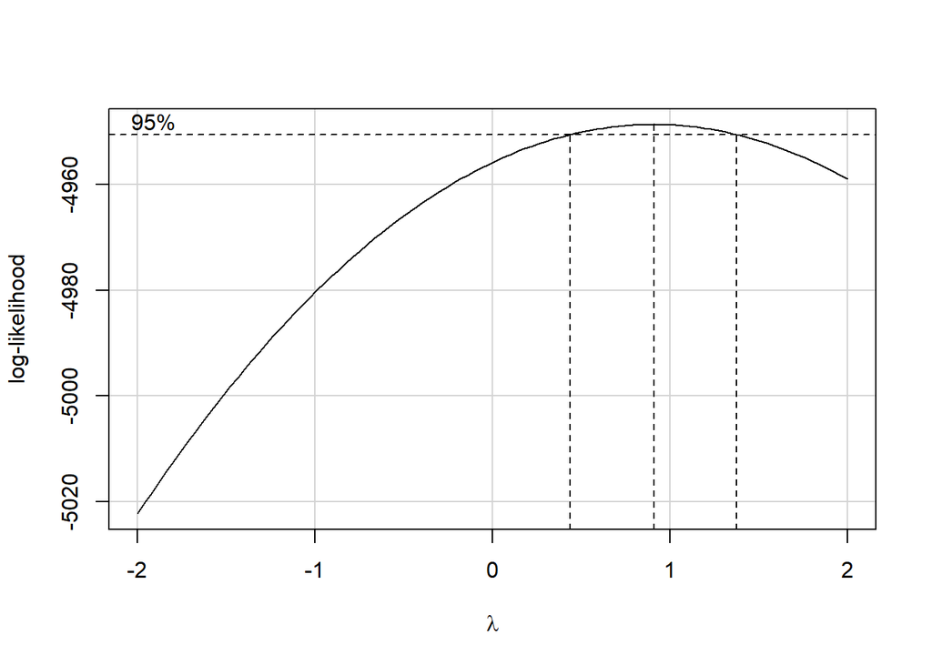

## Adjusted R_squared

Adjusted R_squared formula is

$$R_{adj}^2 = 1 - \frac{(n-1)SSE}{(n-p)SSTO}$$

```r
Y <- (log(mytrain$SalePrice))^(2)

Y_hat <- predict(tlm, mytrain)

sum(Y - Y_hat)
```

```
## [1] 1.490733e-09
```

```r
SSE <- sum((Y - Y_hat)^2)

SSTO <- sum((Y - mean(Y))^2)

n <- nrow(mytrain)

p <- length(t)

adj_Rs <- 1 - ((n - 1)*SSE)/((n - p)*SSTO)
```

**Adjusted R-squared**: 0.7931439

## Validated Adjusted R_squared

```r
Yt <- (log(mytest$SalePrice))^(2)

Yt_hat <- predict(tlm, newdata = mytest)

sum(Yt - Yt_hat)
```

```
## [1] 26.91409
```

```r
SSE <- sum((Yt - Yt_hat)^2)

SSTO <- sum((Yt - mean(Yt))^2)

n <- nrow(mytest)

p <- length(t)

adj_Rs1 <- 1 - ((n - 1)*SSE)/((n - p)*SSTO)
```

**Adjusted R-squared**: 0.7635276

## Graph

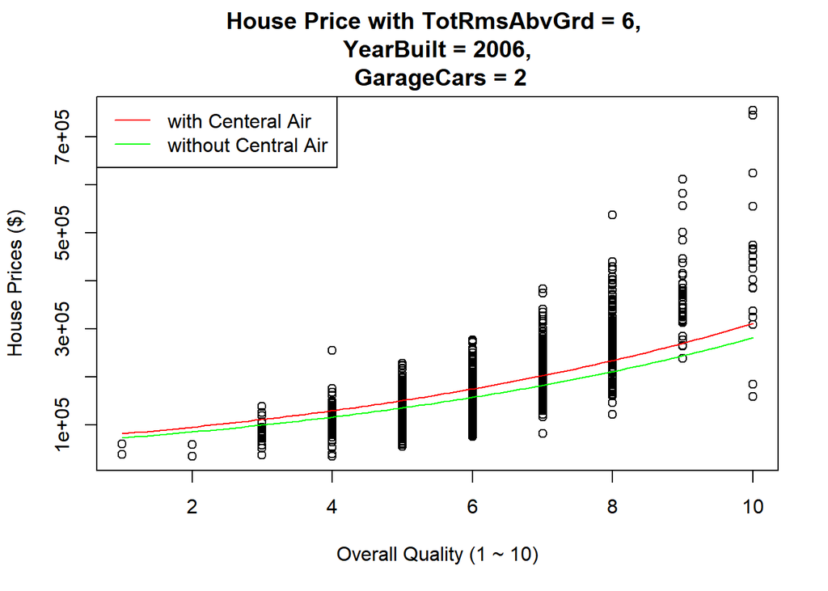

numbers of houses in quality levels

| 1 | 2 | 3 | 4 | 5 | 6 | 7 | 8 | 9 | 10 |
| --- | --- | --- | --- | --- | --- | --- | --- | --- | --- |
| 2 | 3 | 20 | 116 | 397 | 374 | 319 | 168 | 43 | 18 |

The graph gives nice average price of house in between quality level five to 7. However, other than those levels, the regression line could not give nice anticipated house price.

## Interpretation

Using `OverallQual` as a x-variable, I found out my model fits to the original data with 0.7931439. Because the model has four numeric variables, I had to set a number for them except for the x-axis variable. The y-intercept of the model with `Central Air` is $e^{(124.5286)^{1/2}}$ = 70209.46 and without is $e^{(121.9982)^{1/2}}$ = 62647.53. The slope of the model keep changes because of the exponential. The Quality 1 with `Centeral Air` for house price is 82218.39.

## Model Appropriation

```
## [1]  84 471
```

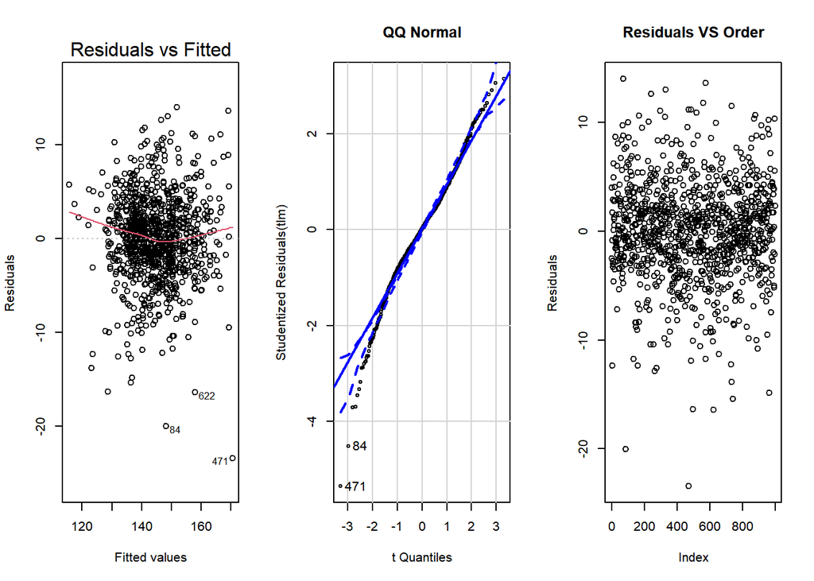

Residuals vs Fitted plot seems to have not good linear relation since the red line curved downward. There are some outliers that makes consistent variation a little weak, and the data are more centered to the center. The data are not perfectly normal, so it is a little questionable. Residual vs Order plot shows that the data are concentrated in the zero horizontal line. These three plots do not look in good fit when they are plotted in small sizes, the data seems okay to use with my model.